# Exploratory Data Analysis on White Wines dataset

Eric Shell

11 April 2018

## Overview of the goals of this investigation

**This report will investigate the possible physical and chemical factors that may contribute to the wine’s judge quality.**

The dataset is available [here](https://s3.amazonaws.com/udacity-hosted-downloads/ud651/wineQualityWhites.csv)

**In this investigation we will look into these questions:**

1. We want to look at the distribution of the raw variables. Are they skewed, or instead are they roughly symmetric and normal or bell shaped?
2. Can we say that increases or decreases in the level of a variable are associated with an increase or decrease in quality?  
   If so, is there a strong or orderly relationship? Does our picture we get in our charts match the picture we get from correlation coefficients? Finally, is the relationship monotic, or is it instead peaked with a neighborhood having highest quality levels?
3. When looking at how the variables relate to each other, can we see some variables moderating the effect that another variable has on quality?
4. We want to know if our intuitions reached from investigating the above questions are born out in a linear regression model. Do the variables that appear to be the most related to quality (graphically, in plots) also have a relatively high amount of variance explained in the linear regression model? And do the variables that we think interact in the ways indicated above also have a correspondingly important interaction term in the regression model?

### Brief overview of the dataset

```
## 'data.frame':    4898 obs. of  13 variables:
##  $ X                   : int  1 2 3 4 5 6 7 8 9 10 ...
##  $ fixed.acidity       : num  7 6.3 8.1 7.2 7.2 8.1 6.2 7 6.3 8.1 ...
##  $ volatile.acidity    : num  0.27 0.3 0.28 0.23 0.23 0.28 0.32 0.27 0.3 0.22 ...
##  $ citric.acid         : num  0.36 0.34 0.4 0.32 0.32 0.4 0.16 0.36 0.34 0.43 ...
##  $ residual.sugar      : num  20.7 1.6 6.9 8.5 8.5 6.9 7 20.7 1.6 1.5 ...
##  $ chlorides           : num  0.045 0.049 0.05 0.058 0.058 0.05 0.045 0.045 0.049 0.044 ...
##  $ free.sulfur.dioxide : num  45 14 30 47 47 30 30 45 14 28 ...
##  $ total.sulfur.dioxide: num  170 132 97 186 186 97 136 170 132 129 ...
##  $ density             : num  1.001 0.994 0.995 0.996 0.996 ...
##  $ pH                  : num  3 3.3 3.26 3.19 3.19 3.26 3.18 3 3.3 3.22 ...
##  $ sulphates           : num  0.45 0.49 0.44 0.4 0.4 0.44 0.47 0.45 0.49 0.45 ...
##  $ alcohol             : num  8.8 9.5 10.1 9.9 9.9 10.1 9.6 8.8 9.5 11 ...
##  $ quality             : int  6 6 6 6 6 6 6 6 6 6 ...
```

The dataset has these variables seen from the summary, in their order of appearance above:

*x*: an index which is ignored

*fixed acidity* (tartaric acid - g / dm<sup>3</sup>): most acids involved with wine or fixed or nonvolatile (do not evaporate readily)

*volatile acidity* (acetic acid - g / dm<sup>3</sup>): the amount of acetic acid in wine, which at too high of levels can lead to an unpleasant, vinegar taste

*citric acid* (g / dm<sup>3</sup>): found in small quantities, citric acid can add ‘freshness’ and flavor to wines

*residual sugar* (g / dm<sup>3</sup>): the amount of sugar remaining after fermentation stops, it’s rare to find wines with less than 1 gram/liter and wines with greater than 45 grams/liter are considered sweet

*chlorides* (sodium chloride - g / dm<sup>3</sup>: the amount of salt in the wine

*free sulfur dioxide* (mg / dm<sup>3</sup>): the free form of SO<sub>2</sub> exists in equilibrium between molecular SO<sub>2</sub> (as a dissolved gas) and bisulfite ion; it prevents microbial growth and the oxidation of wine

*total sulfur dioxide* (mg / dm<sup>3</sup>): amount of free and bound forms of SO<sub>2</sub>; in low concentrations, SO<sub>2</sub> is mostly undetectable in wine, but at free SO<sub>2</sub> concentrations over 50 ppm, SO<sub>2</sub> becomes evident in the nose and taste of wine

*density* (g / cm<sup>3</sup>): the density of water is close to that of water depending on the percent alcohol and sugar content

*pH*: describes how acidic or basic a wine is on a scale from 0 (very acidic) to 14 (very basic); most wines are between 3-4 on the pH scale

*sulphates* (potassium sulphate - g / dm3): a wine additive which can contribute to sulfur dioxide gas (SO<sub>2</sub>) levels, which acts as an antimicrobial and antioxidant

*alcohol* (% by volume): the percent alcohol content of the wine

*quality*: score between 0 and 10

As can be seen above, all these variables of interest are numerical measures of chemical properties of the wine, aside from the quality rating itself which is a subjective 0 - 10 rating.

## Univariate Plots Section

**Here we look at the histograms and distribution characteristics for the different variables. We start off by looking at the main variable of interest, quality.**

We can see below that the distribution of quality ratings is roughly symmetric, and the typical values range between 5, 6, and 7, with less rated 4 or 8 and a few outliers rated at 3 or 9. It’s a little curious that there are so few rated above 8 or below 4, and with none rated as 0, 1, or 2.

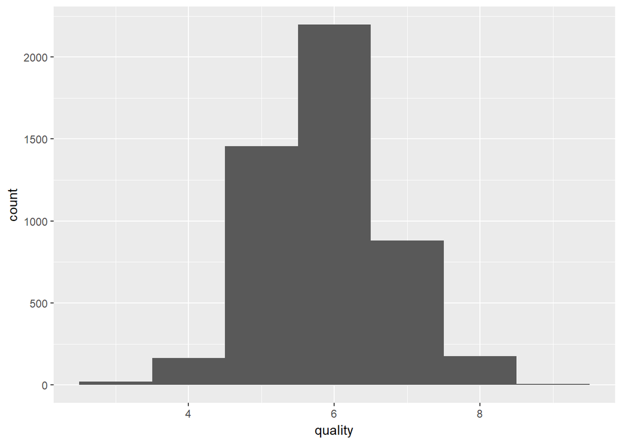

```
##    Min. 1st Qu.  Median    Mean 3rd Qu.    Max.
##   3.000   5.000   6.000   5.878   6.000   9.000
```

```
##
##    3    4    5    6    7    8    9
##   20  163 1457 2198  880  175    5
```

**Next, we look at the alcohol level, which again is percent alcohol of the wine.**

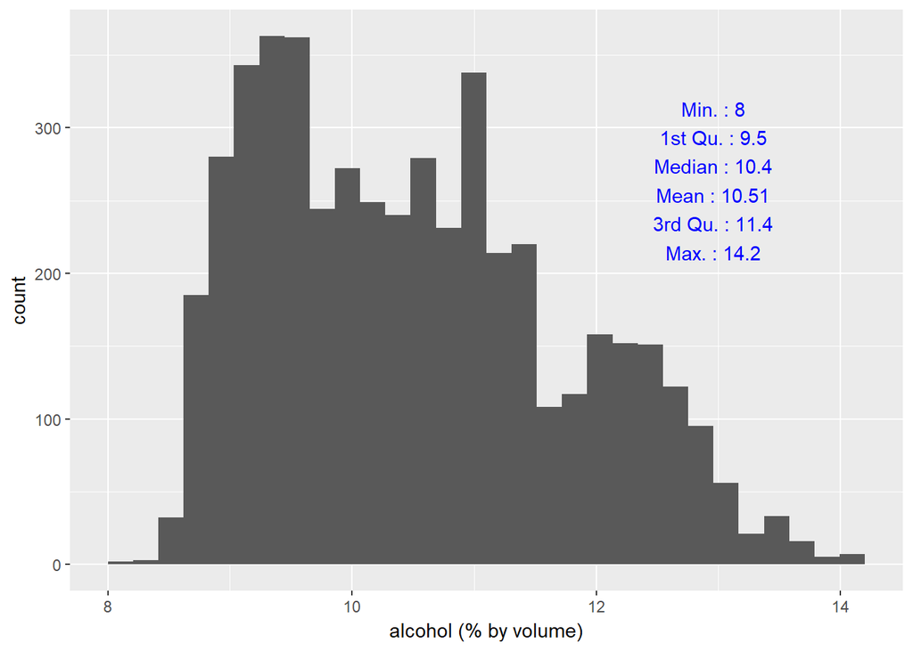

We see a moderately right-skewed distribution for the alcohol content, with a spike at around 8.5 to 9.5%, with the frequencies falling off after that. There are hints of a bi-modal distribution with another mini-spike at around 12%, possibly reflecting a recognizable type of white wine (say, of white zinfandel) that typically contains more alcohol. (Note, however, that according to the data source, the types of white wine like this are not included in the analysis due to copyright reasons.)

**Next, we take a look at the density.**

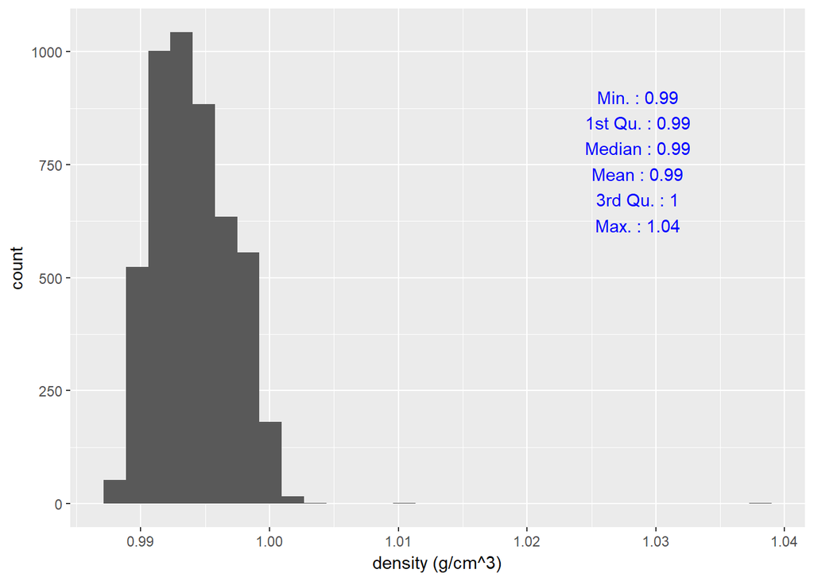

```
##
## [0.985,0.995]     (0.995,1]      (1,1.01]   (1.01,1.02]   (1.02,1.03]
##          3098          1797             2             0             0
##   (1.03,1.04]
##             1
```

The density has a symmetric, normal or bell-shaped distribution, with just 3 outliers past the density of 1.0 which we take a note of here.

**We now look at residual sugar level.**

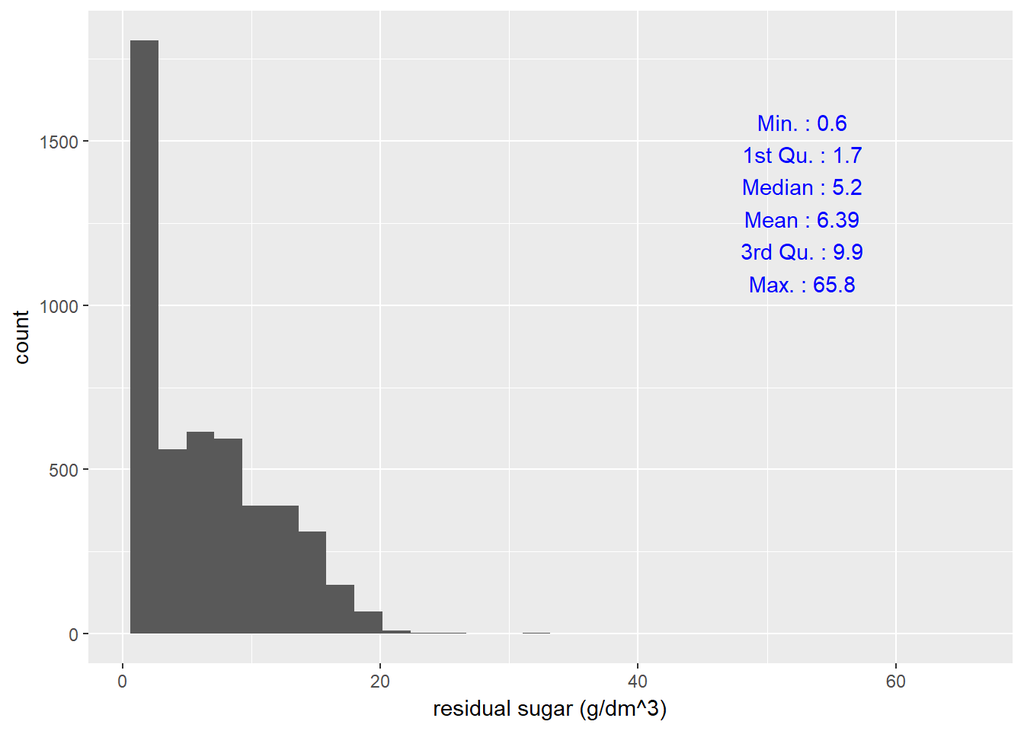

```
##
##  [-5,5]  (5,15] (15,25] (25,35] (35,45] (45,55] (55,65] (65,75]
##    2410    2167     316       4       0       0       0       1
```

Similar to density, the distribution for residual sugar is also heavily right skewed with just 5 outliers past the typical value of 25 g/dm<sup>3</sup>. Rather than being almost symmetric, this distribution looks like the frequency is a decreasing function of the sugar level, with the most common level being very low.

**Next, we look at chlorides**

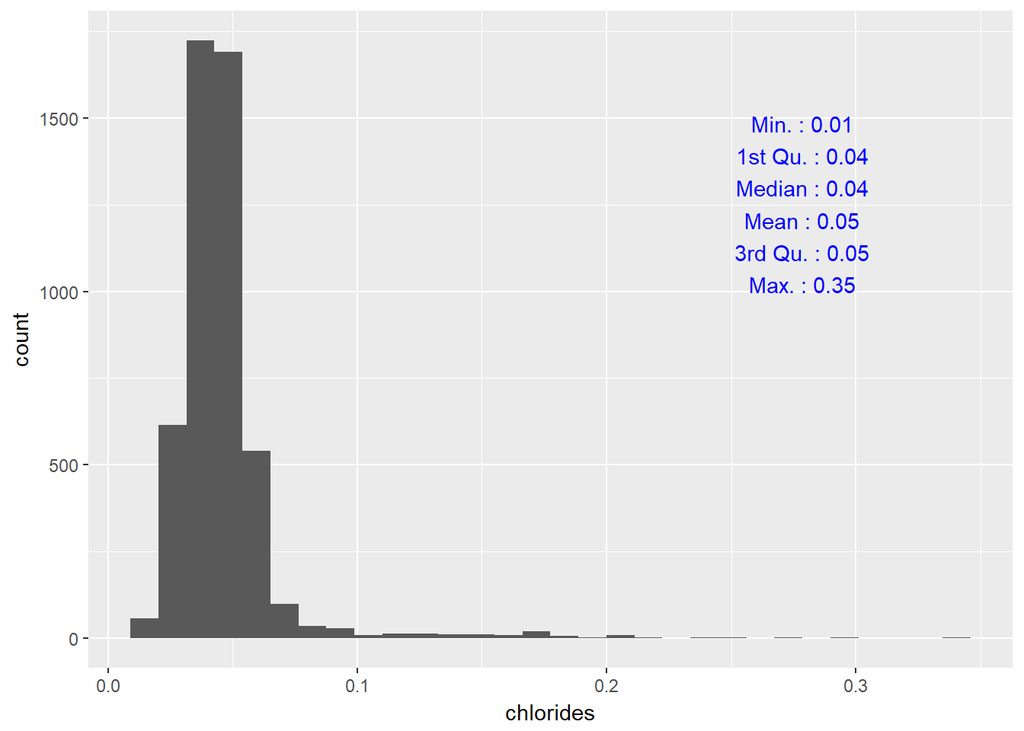

```
##
## [-0.025,0.025]  (0.025,0.075]  (0.075,0.125]  (0.125,0.175]  (0.175,0.225]
##            178           4536            100             54             22
##  (0.225,0.275]  (0.275,0.325]  (0.325,0.375]
##              5              2              1
```

The chlorides frequency distribution is roughly symmetrical and normal shaped, with a heavy right tail having frequencies gradually dropping off as the chlorides rate increases, as opposed to just a few outliers after a cut-off point like was seen with density and sugar level.

**To simplify, we look at the variables relating to sulfates together below.**

As mentioned above, sulfates are added for quality control to reduce microbial growth, but in too large of quantities it can be noticeable to the taste and smell.

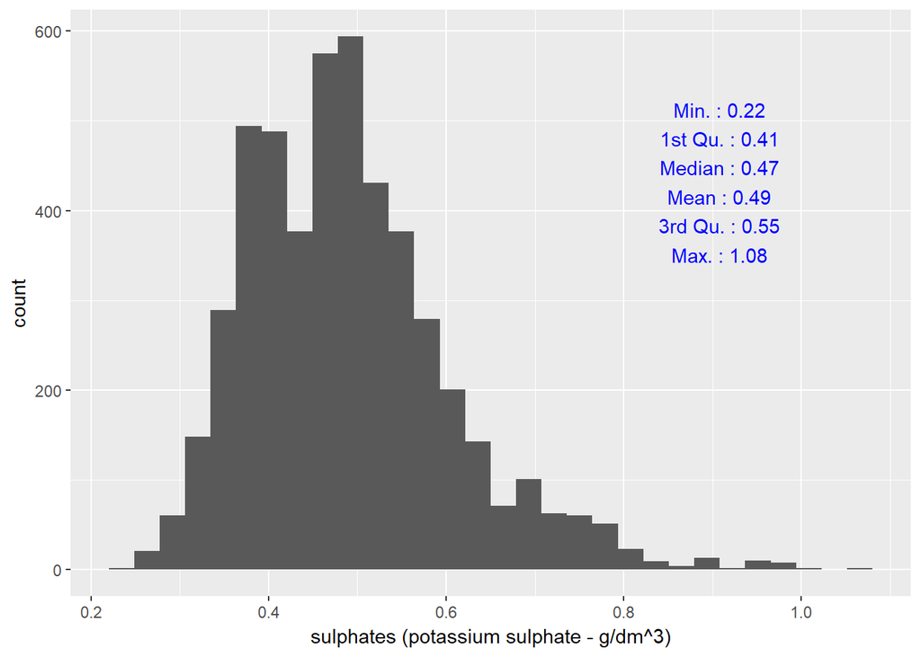

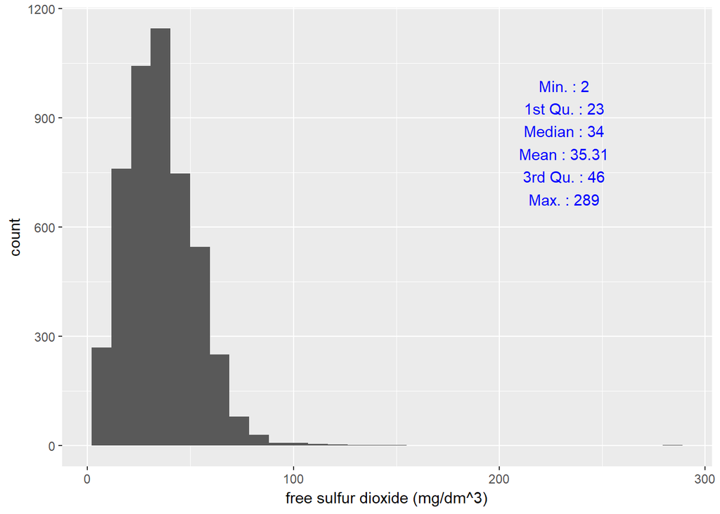

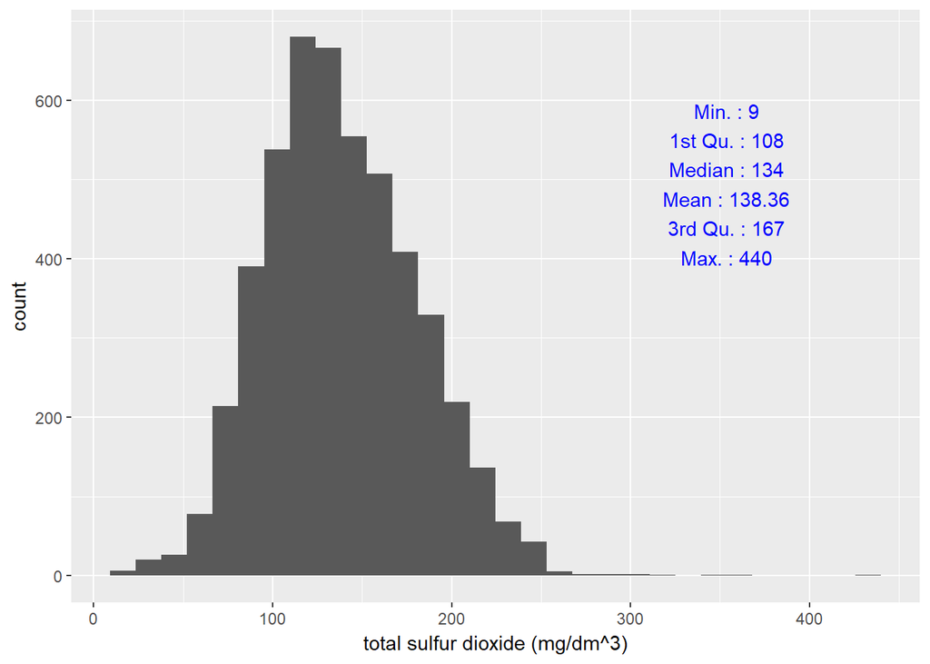

These distributions all look relatively symmetric and normal (bell-shaped).  
There appear to be outliers well outside the typical range for free sulfur dioxide, but not so much for total sulfur dioxide, and no significant amount of outliers for the sulfates level itself.

**We now look at the variables associated with acidity together, again to simplify the analysis.**

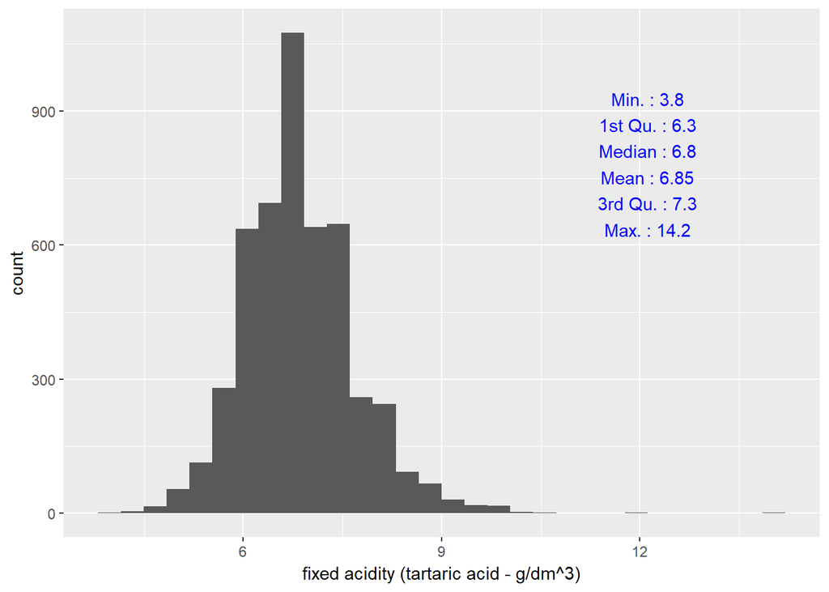

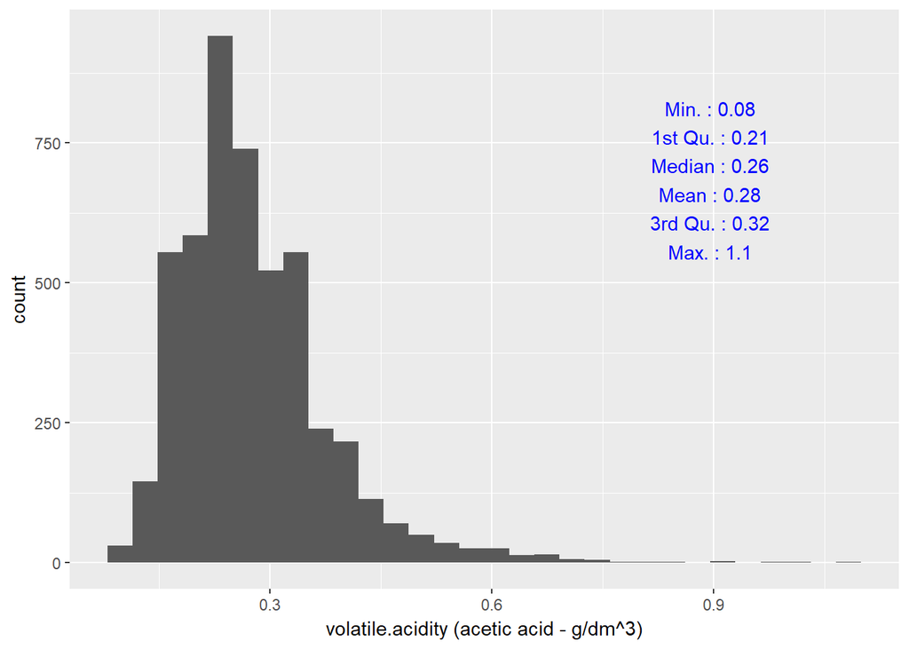

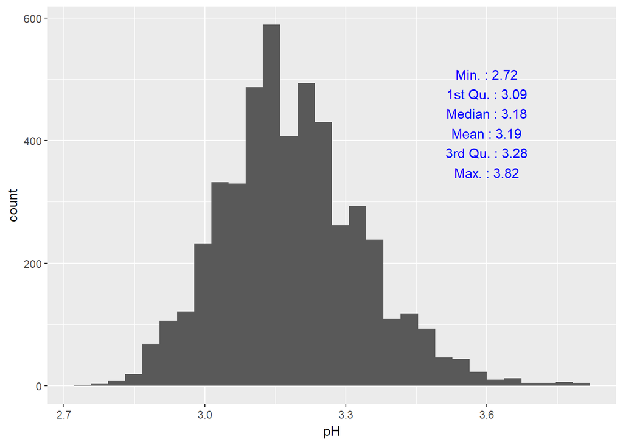

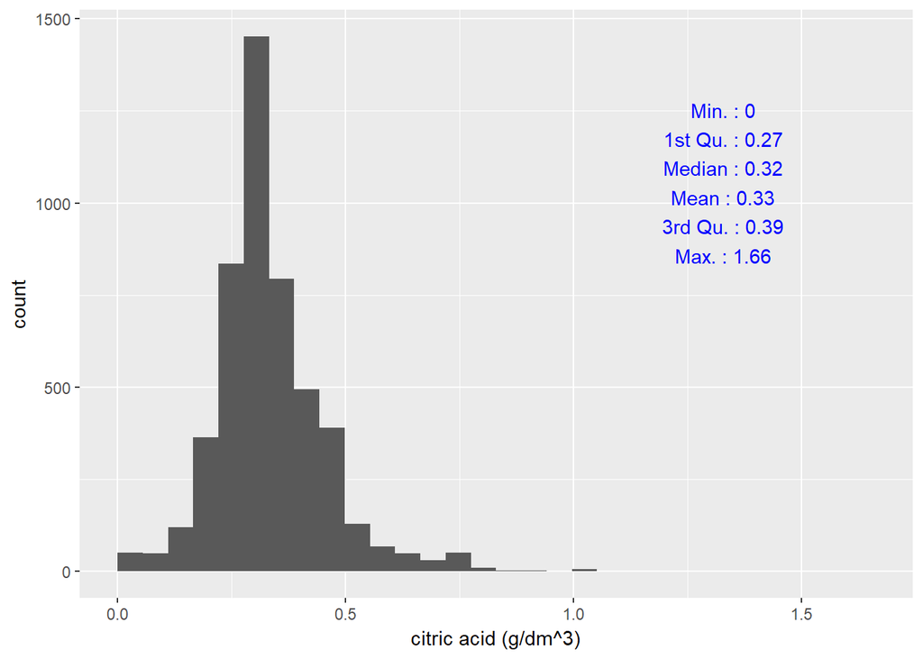

All of the frequency distributions for the acid-related variables are roughly symmetric and normal shaped. The means are fairly close to the median, although not as much with volatile acidity, which shows a hint of right-skewedness. All variables except pH appear to have outliers lying outside the typical range, with the outlier regions having roughly half of the range on the x-axis.

Again, it looks like with a couple exceptions, most variables have a somewhat normal distribution. To test this impression, we pick two variables that look like they have a non-normal distribution, and two variables that look like they have a normal distribution, and then we do quantile-quantile plots to verify the intuitions.

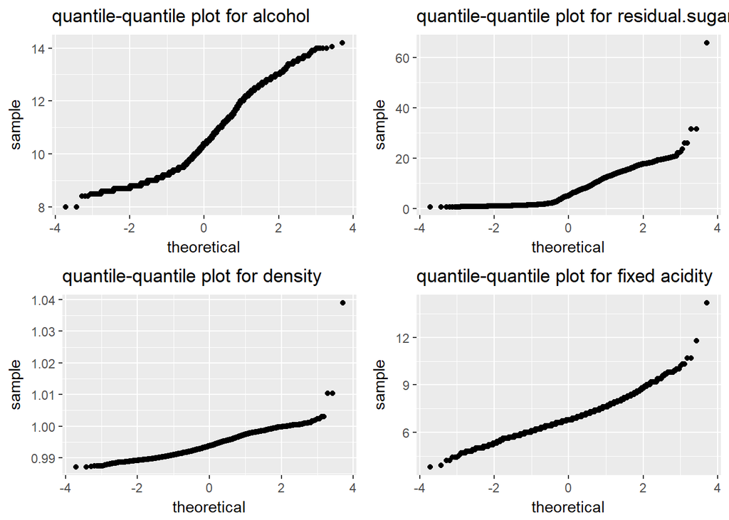

This looks like we have the upper two quantile-quantile plots showing less of a straight line than the lower two quantile-quantile plots. The plot for alcohol looks sigmoid-like (S shaped), while that for sugar level has an abrupt transition where the slope changes. The two bottom plots, on the other hand, look as straight as can be expected.

## Univariate Analysis

Quality looks like a roughly symmetric, bell shaped distribution, ranging from ratings of 3 to 9, with the vast majority of quality ratings being either 5, 6, or 7, with a mean of about 5.9 and just a small number of wines rated as 3 or 9. It would seem like there are not a lot of oustanding or poor wines in the sample, at least according to the quality rating.

With the exception of alcohol and residual sugar level, the histograms looked essentially normal or bell shaped. We checked this impression by doing some quick quantile-quantile plotting, and indeed the q-q plots for residual sugar and alcohol levels were less straight then those for two variables which appeared normally distributed, density and fixed acidity.

## Bivariate Plots Section

**We now take a look at the relationships between the variables and quality.**

Again, we want to know if there is a regular, well behaved relationship, if this relationship is uniform or instead it has both increasing and decreasing quality in areas, and if these relationship trends are observed for the majority of the distribution, excluding the outliers. And finally, we want to know if these relationships to quality match what we see looking at the Pearson’s correlation coefficients.

I found it cumbersome to cross correlate all the variables as seen in a ggpairs plot, so I created this correlation heatmap from code I found [here](http://www.sthda.com/english/wiki/ggplot2-quick-correlation-matrix-heatmap-r-software-and-data-visualization)

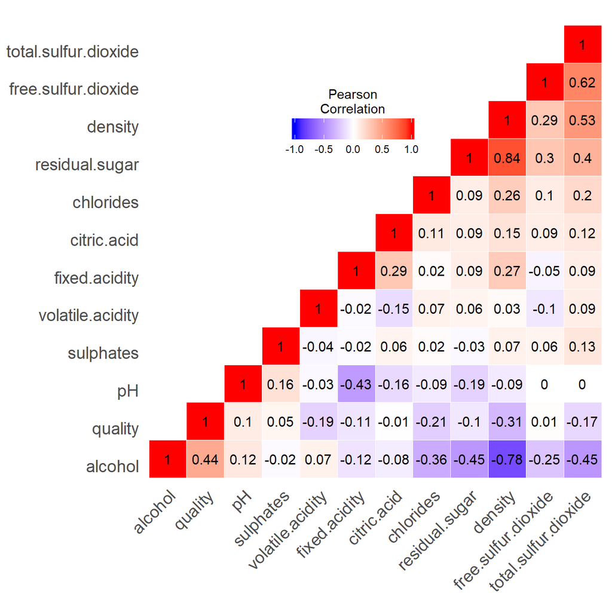

Looking at the correlation heatmap, we see just a few variables that appear to be moderately associated with quality. *Alcohol* has the most significant correlation at 0.44, followed by *density* at -0.31, *chlorides* at -0.21, *volatile acidity* at -0.19 and *total sulfur dioxide* at -0.17. There are other variables with a lesser but perhaps important degree of correlation, but we can make a cut-off to focus more closely on these variables as quality factors, keeping in mind that other variables might play a role in interacting with the variables just mentioned.

We make one more observation, noting that the variables alcohol and density, both of which may have a significant relationship to quality, themselves appear to be correlated with each other, as does density and residual sugar. This is not surprising, considering that density is affected by both alcohol and sugar level.

**We will now take a look plotting each variables’ association with quality, focusing on the variables identified above having a possibly significant correlation with quality.**

Before we do any aggregations or transformations, it’s best to look at the raw data, and the most straightforward way to do this is with the scatterplots of the variable versus the quality. We do this below with alcohol.

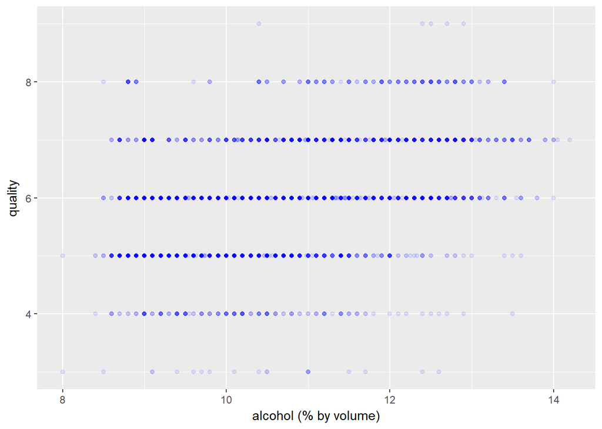

If we try, we can somewhat get an understanding here of how alcohol content relates to quality. For instance, by comparing the wines with an 8 quality rating against the wines with a 4 or 5 rating, we see that the higher quality wines have a higher average alcohol content on average than the lower quality wines. But this is a rather indirect inference, and we don’t see, for instance, what the average alcohol content is for each quality level.

So we try using a boxplot with the mean alcohol content to see if this gives us a better, more direct picture showing the means and how they change with quality.

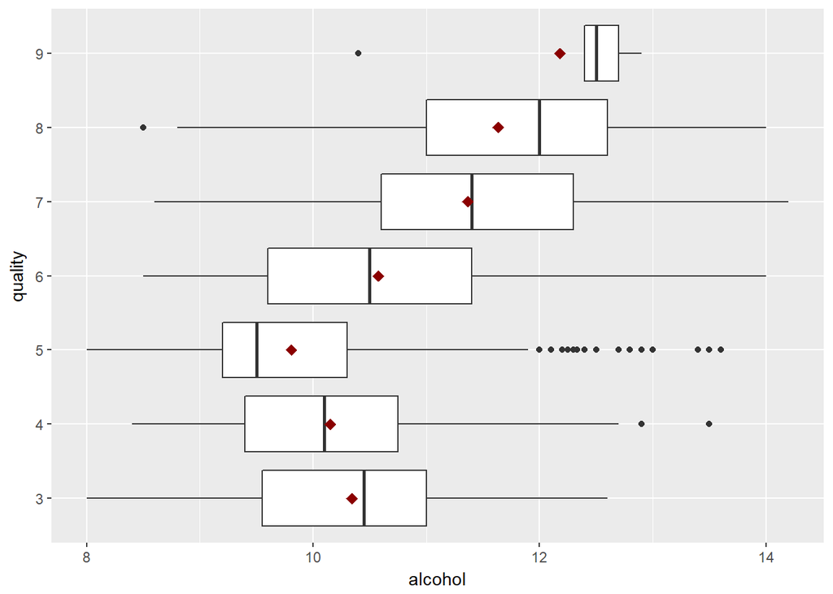

So this gives us roughly the same information as we got from the scatterplot, and we get a more direct comparison of how the mean alcohol levels change across the different quality levels. For example, we clearly see the mean alcohol level (as red diamonds) increasing for wines with qualities 5 and above. This graphically illustrates quality increasing with increasing alcohol content, which is what we want to show.

But by the same token, it misleads just a bit because it shows the alcohol content means *decreasing* as the quality increases from 3 to 5. When we look at the scatterplot we can immediately see that there are relatively few wines having these qualities and so can de-emphasize this trend, but we don’t get such an indication here with the box plots; the wines with qualities 3 and 4 are given equal “weight” since they are included in the plot. We conclude from this that the scatterplot gives a more informative picture.

But we are still not getting the effect we want from the plots, which is to show directly how the quality varies over changes in the variable(s) of interest. We extrapolate with the scatterplots and boxplots how quality *should* be increasing or decreasing with the variable, without actually figuring out what the average quality is for a given range of the variable of interest.

So we try working more directly with the average quality, and see how that varies with the changes in the variable(s). Now we calculate the mean quality for a range (bin) of alcohol levels.

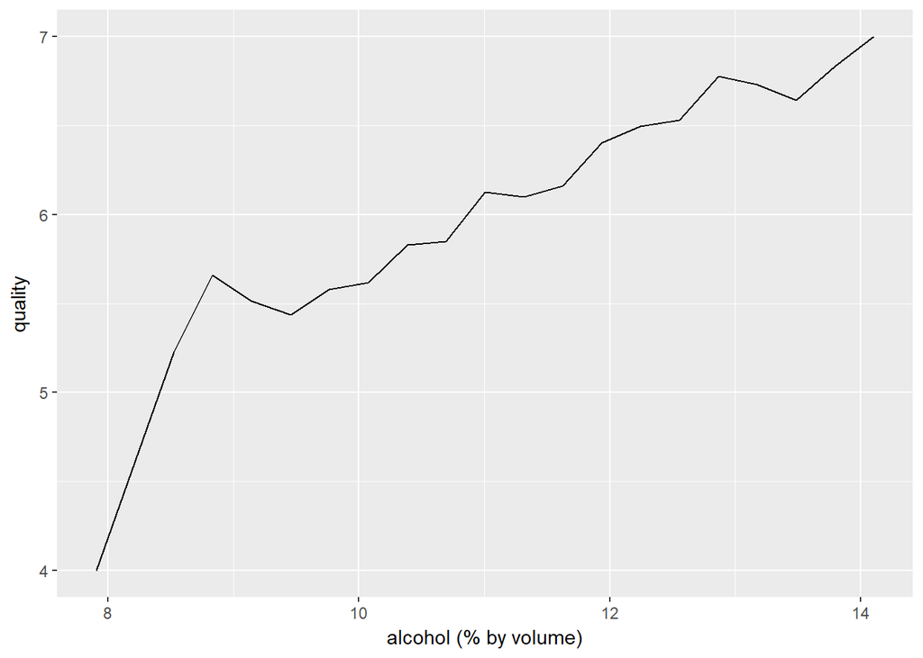

Here we see a nice, straight-ish line demonstrating quality increasing with increasing levels of alcohol. *Finally*, something that looks like a relationship, with changes in one thing associated with changes in quality, which is what we are ultimately interested in!

We do the same for density (below), and we run into a new problem.

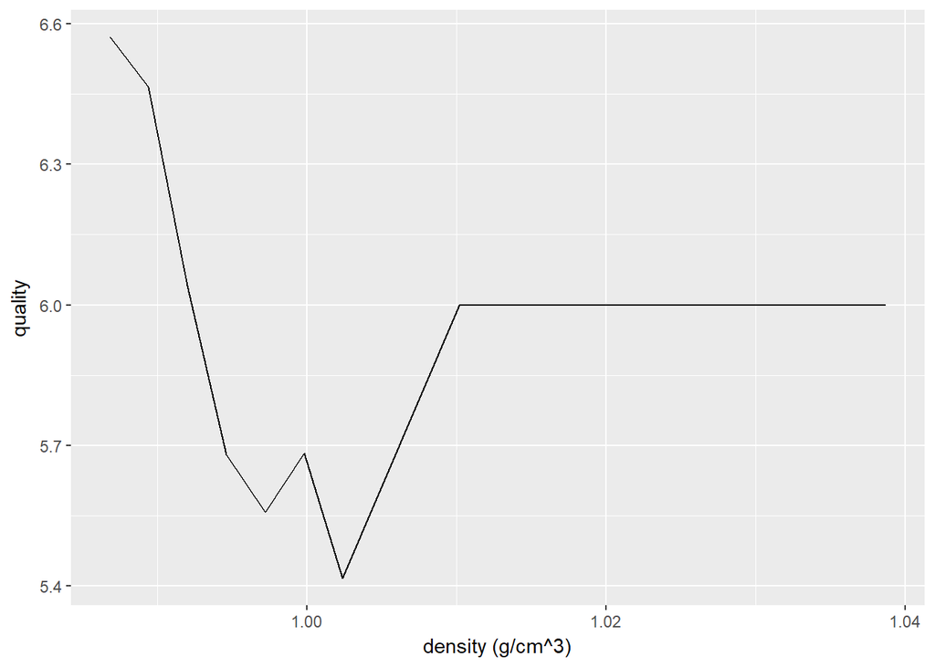

The problem is that this plot includes the outliers, taking up almost half of the plot space, without an indication this is the case. But if we just take out the outliers, we also might be leaving out information that could be useful later. So a compromise would be to include the outliers and put indications where they lie. In the following plots we do this by using vertical bars to mark off the top and bottom 1% quantiles.

With these improvements in hand, we now show the plots for all variables against quality.

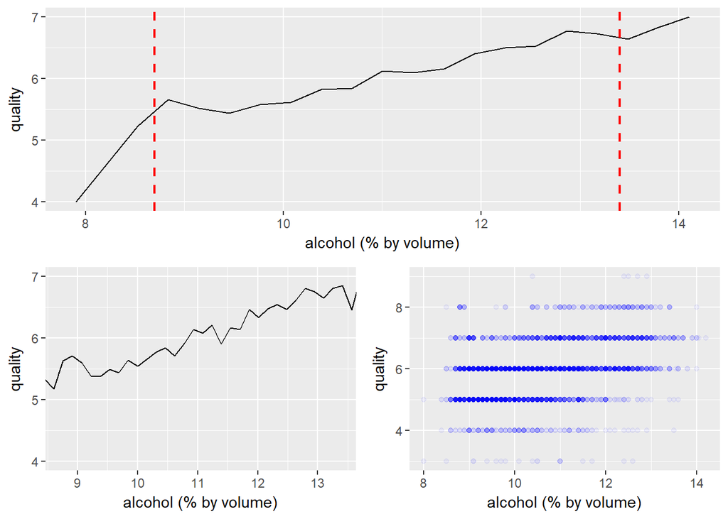

As indicated earlier, we see a clear linear relationship here between *alcohol* level and quality, and moreover this persists throughout the high and low ends of alcohol level. This is in agreement with the relatively high (0.44) correlation coefficient between alcohol and quality.

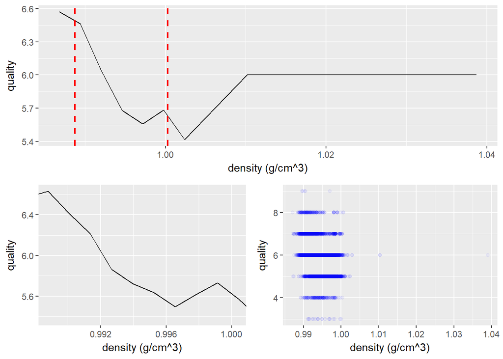

Looking at *density*, we see a mostly decreasing relationship between density and quality, in agreement with the negative correlation coefficient (-0.31) between it and quality. Its notable that so small a region of the plot is actually occupied by the area where most densities lie. Above the density of 1.0 the relationship becomes less regular.

As density has a less regular relationship with quality than alcohol, it’s possible that the correlation with quality could come about mainly through its correlation with alcohol, which we will explore later.

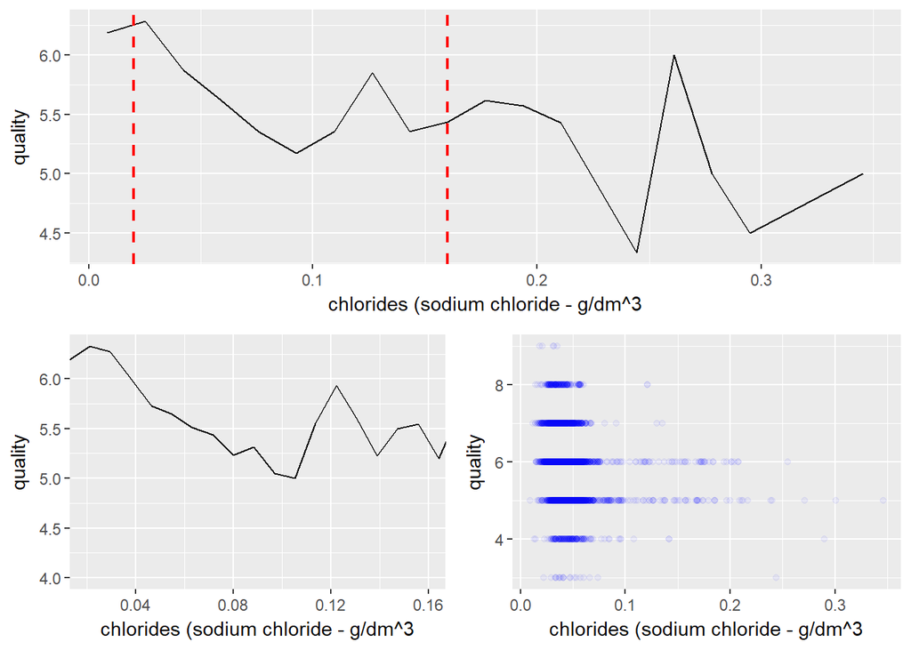

The plot between *chlorides* level and quality does not show a regular, uniform relationship. We can certainly ignore for now the wildly fluctuating mean quality values within the outlier regions, but even ignoring these we do not any regular trend that can be seen. It may be that there is no monotonic or even regular relationship to be captured here. This is curious since chlorides has the third highest correlation coefficient among all the variables.

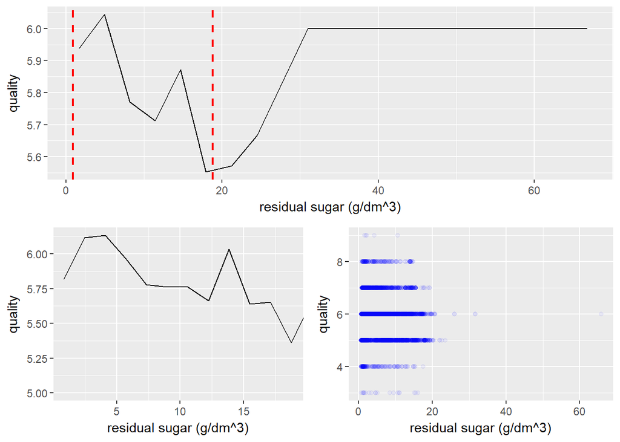

The plot for *residual sugar* has much in common with the plot for density, in that there is an irregular up and down pattern throughout the essentially decreasing relationship. And as with density, the trend does not persist in the outlier regions.

Since sugar is so strongly correlated with density and sugar has a much lower correlation to quality than density, we may be just seeing the reflected relationship of density to quality here.

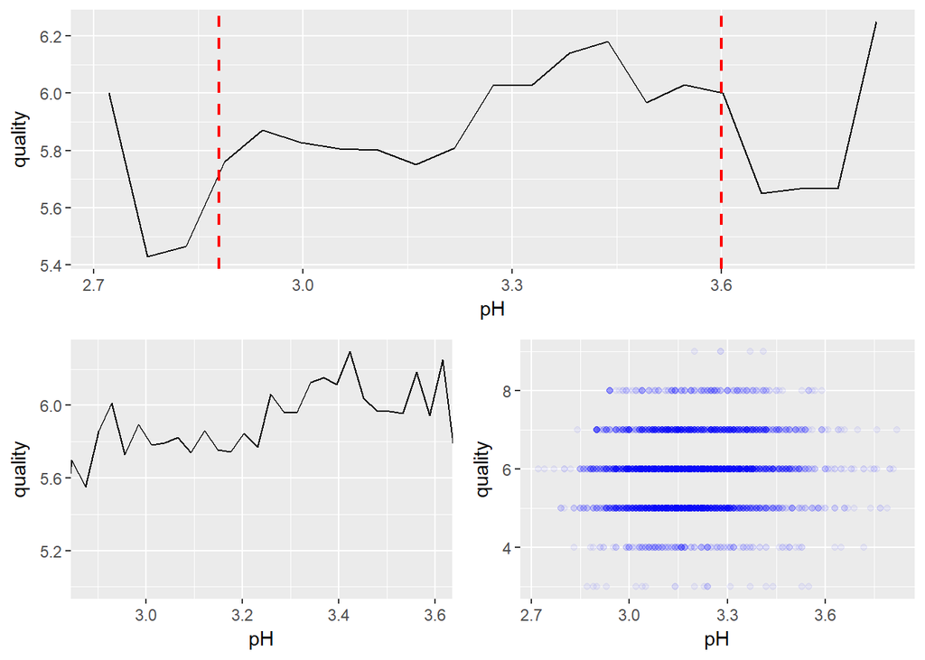

The plot for *pH* versus quality is somewhat more orderly. We see some hints of a peaked relationship, suggesting a possible near-optimal pH level for quality around 3.4. It is an interesting possibility that pH could have an orderly relationship with quality but that the effects of the upper and lower regions of pH values cancel to obscure the relationship for a correlation coefficient and a linear model. If this were the case, the small 0.1 correlation with quality would be misleading.

The irregular shapes in the outlier regions for pH may be an artifact of having fewer samples for the outliers.

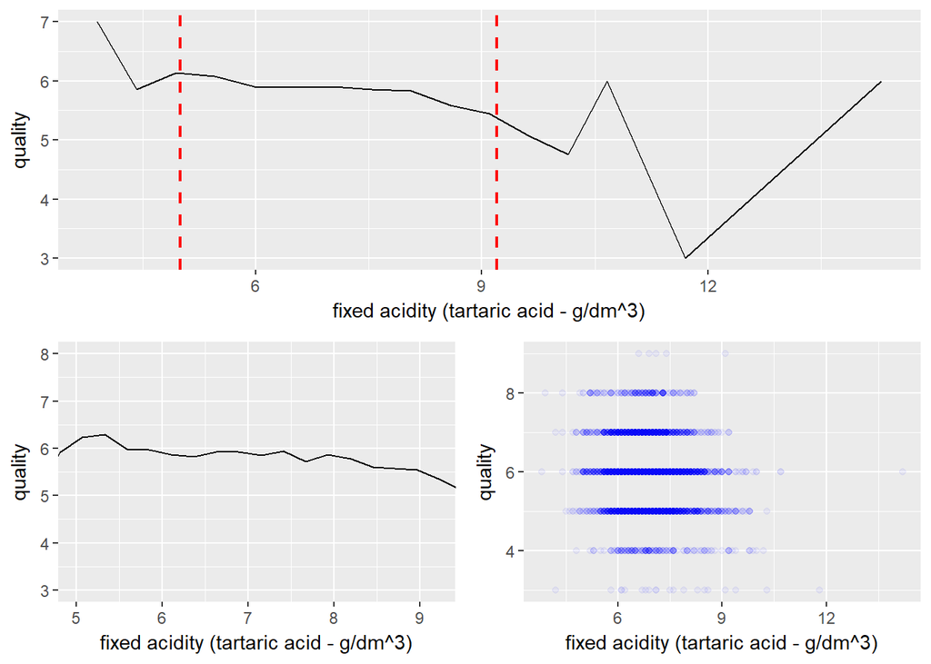

*Fixed acidity* shows a very slight decreasing relationship between it and quality, but the plot is mostly flat, which suggests we can mostly ignore its effect on quality.

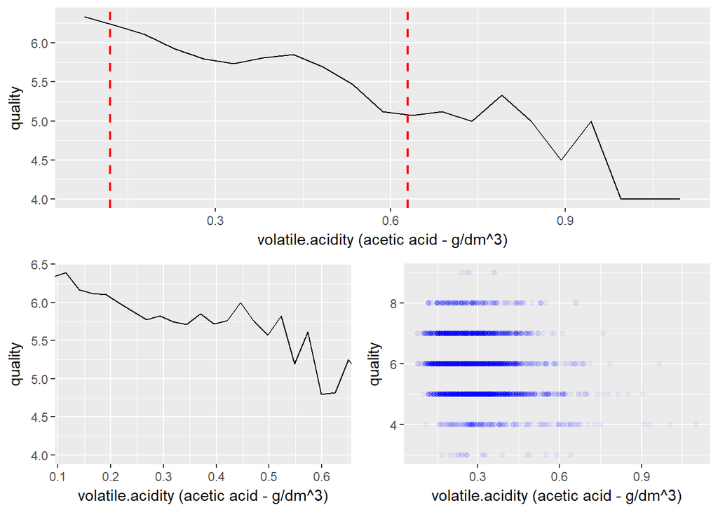

In contrast, *volatile acidity* shows a regular, mostly linear and decreasing relationship between it and quality. This relationship persists in the outlier regions.

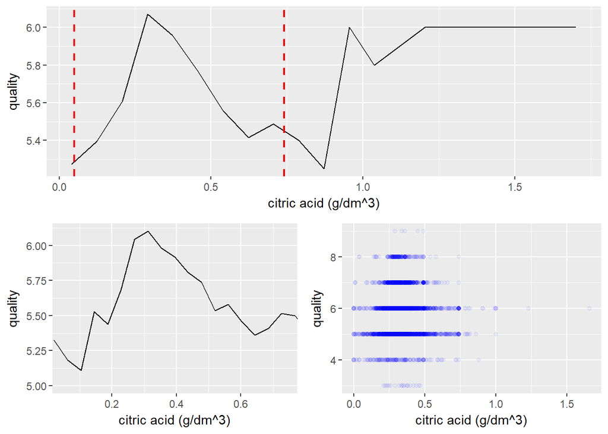

*Citric acid* has a very peaked relationship with quality, suggestive of a possible optimal region in terms of quality. But from the description of the variables given, there is no suggestion that too much citric acid causes bad side effects, and it is usually only seen in small quantities, so perhaps there is an unappreciated side effect of excess citric acid, or the appearance of an optimal level is illusory.

We will investigate this further when we look more closely at the variables with peak quality neighborhoods.

We now look at the sulfur-related variables, starting with the *sulphates* measure itself.

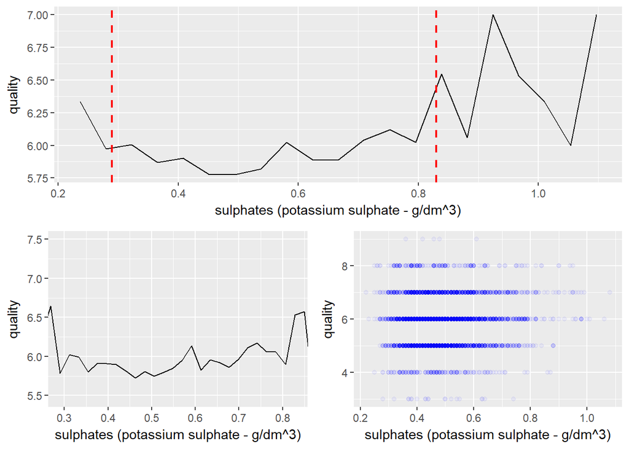

Looking at the *sulphates* levels (*above*) it’s hard to tell if there is low point quality-wise for *sulphates* here, or if instead it is an essentially flat relationship. But a low point in the middle of the range does not make as much sense, since we could expect a point of not enough sulfur risking microbial growth, and a point of too much sulfur when the smell and taste becomes noticeable, so if anything there should be a *peak* of quality at a “sweet spot”.

And this looks like what we see below with *total sulfur dioxide*.

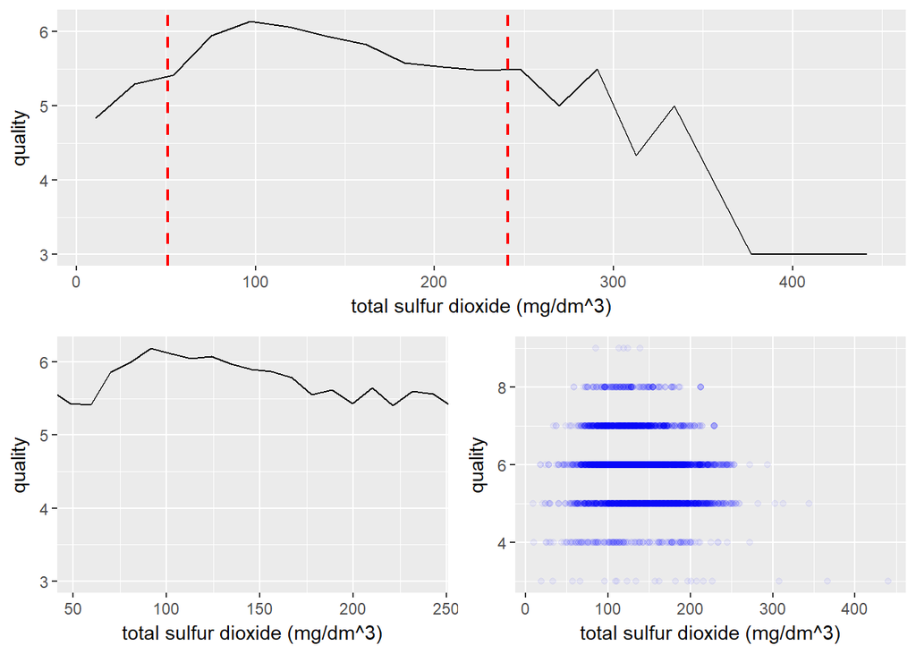

This is suggestive of the aforementioned “sweet spot” of not too little microbial effect and not too much sulfur taste and smell. The quality increases and peaks at around 100, and then drops off.

The trend looks solid, as there is not a whole lot of wigglyness on the line before and after the putative quality peak, and the decreasing quality trend after the peak continues in the outlier region.

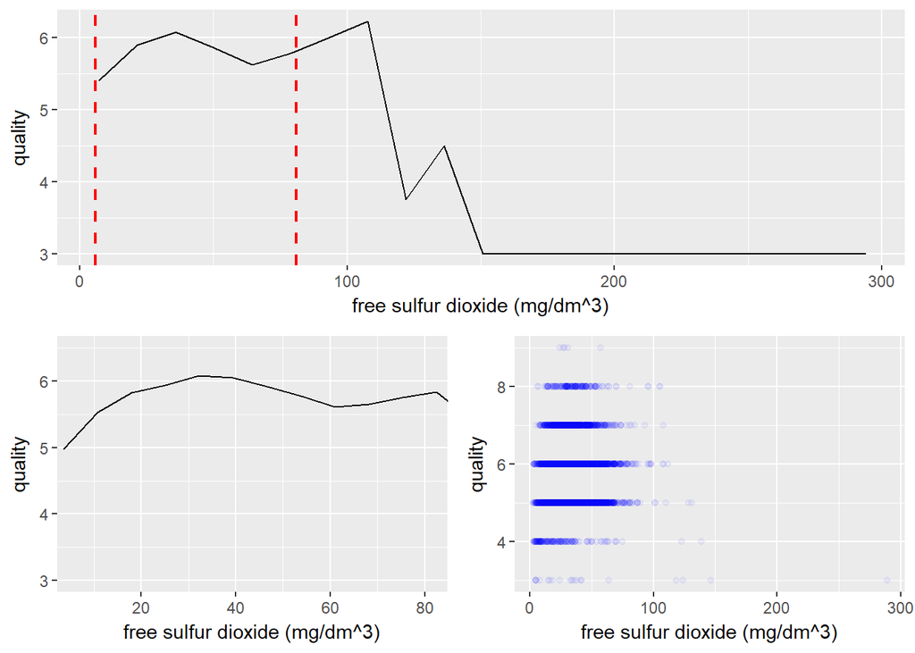

There *could* be a peak quality neighborhood for *free sulfur dioxide*, but it does not inspire as much confidence as does total sulfur dioxide, as there could be a second time where quality increases, but it is hard to know if this is largely due to an errant high quality point for a few outliers.

The peaked relationships to quality are examples of a *nonlinear relationship*. We take a closer look at some of the variables to see if a suitable transformation makes the plots against mean quality appear more linear.

We noted before that pH, total sulfur dioxide, and citric acids may have areas of peak quality. We try out a transformation with the squared value, as a peak could correspond roughly to the maximum of a parabola. We rule out looking at a log or exponential or square root transformation, as these would not be expected to produce an increasing and then decreasing value.

As can be seen below, *there was some improvement in the straightness after transforming the square of total sulfur dioxide.*

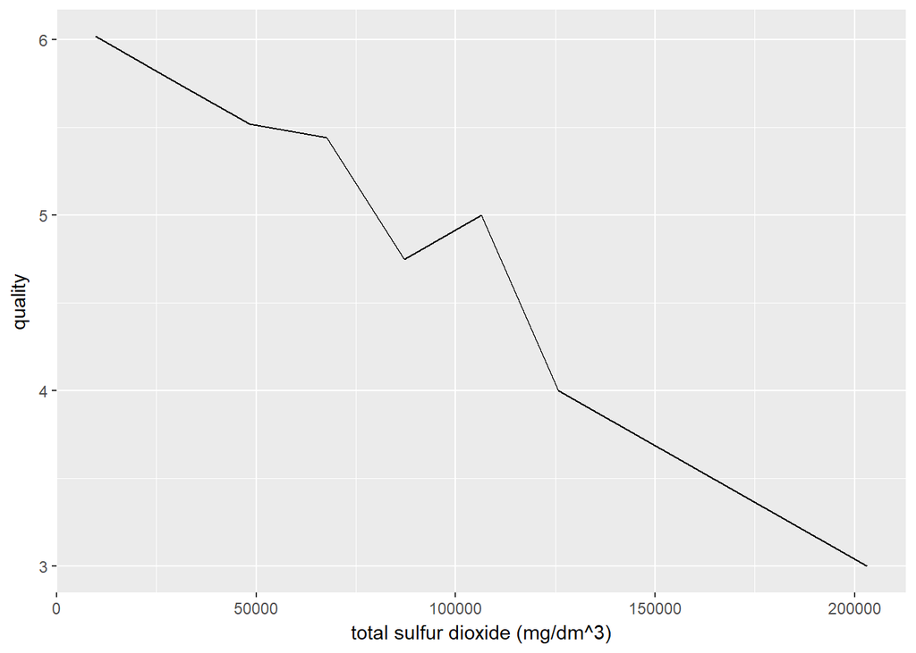

*But the peaks remained for mean quality versus pH and citric acid level after transforming* by the squared value (*below*) and using multiple possible bin sizes.

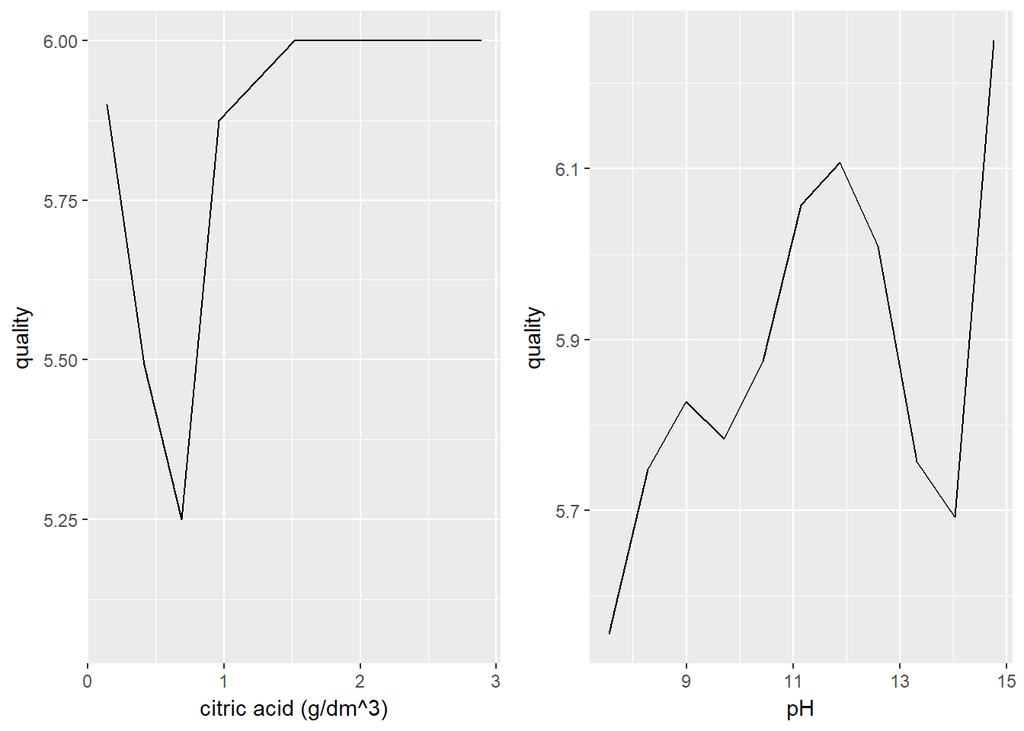

We note in passing that for *volatile acidity* a square root and/or a log transform resulted in a *fairly* linear relationship (i.e. constant slope) when plotted against mean quality for the majority of values that volatile acidity takes (i.e. outside the outliers) (*see below*).

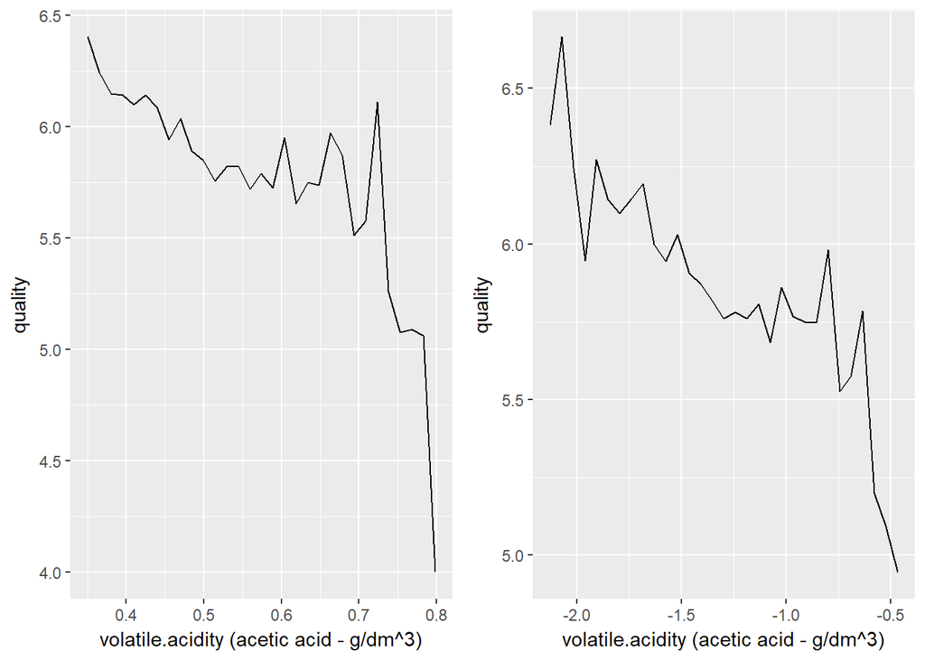